# MAM 2023 Pre-programme Assignment

Vivian van Oosten

27/08/2022

The goal is to test your software installation, to demonstrate competency in Markdown, and in the basics of `ggplot`.

# Task 1: Short biography written using markdown

My name is Vivian, see a picture of me below for reference. Most recently, I worked at [Oliver Wyman](https://www.oliverwyman.com/nl.html) as a *consultant*, which involved a surprising amount of powerpoint slides. My background in *data science* and *mathematics* was not useful, except when it came to the creation of graphs to put in those slides. In the future, I hope to work somewhere more data-based, which is why I’m in this program.

I attended University College Utrecht, where I majored in *economics* and *mathematics*. Some of my favorite academic-related moments are with the economics book club, where we for example talked about crypto- and altnerative currencies with the founder of the Utrecht Euro. My internship with [Stater](https://stater.nl/en/) was another highlight to apply my theoretical knowledge in practice.

In my spare time, I love to read. My favorites are fantasy books, as they provide an escape from reality. Find below a list of my absolute favorite authors, all of whom wrote many books within the same fantasy world.

- Robin Hobb - all of her work
- Anne McCaffrey - the Pern novels
- Raymond E. Feist - everything related to Midkemia

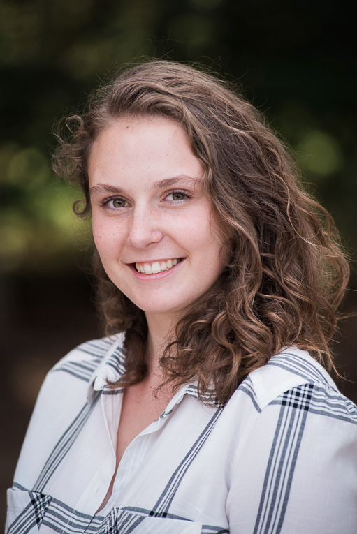

# Task 2: `gapminder` country comparison

You have seen the `gapminder` dataset that has data on life expectancy, population, and GDP per capita for 142 countries from 1952 to 2007. To get a glimpse of the dataframe, namely to see the variable names, variable types, etc., we use the `glimpse` function. We also want to have a look at the first 20 rows of data.

```r
glimpse(gapminder)
```

```
## Rows: 1,704
## Columns: 6
## $ country   <fct> "Afghanistan", "Afghanistan", "Afghanistan", "Afghanistan", …
## $ continent <fct> Asia, Asia, Asia, Asia, Asia, Asia, Asia, Asia, Asia, Asia, …
## $ year      <int> 1952, 1957, 1962, 1967, 1972, 1977, 1982, 1987, 1992, 1997, …
## $ lifeExp   <dbl> 28.801, 30.332, 31.997, 34.020, 36.088, 38.438, 39.854, 40.8…
## $ pop       <int> 8425333, 9240934, 10267083, 11537966, 13079460, 14880372, 12…
## $ gdpPercap <dbl> 779.4453, 820.8530, 853.1007, 836.1971, 739.9811, 786.1134, …
```

```r
head(gapminder, 20) # look at the first 20 rows of the dataframe
```

```
## # A tibble: 20 × 6
##    country     continent  year lifeExp      pop gdpPercap
##    <fct>       <fct>     <int>   <dbl>    <int>     <dbl>
##  1 Afghanistan Asia       1952    28.8  8425333      779.
##  2 Afghanistan Asia       1957    30.3  9240934      821.
##  3 Afghanistan Asia       1962    32.0 10267083      853.
##  4 Afghanistan Asia       1967    34.0 11537966      836.
##  5 Afghanistan Asia       1972    36.1 13079460      740.
##  6 Afghanistan Asia       1977    38.4 14880372      786.
##  7 Afghanistan Asia       1982    39.9 12881816      978.
##  8 Afghanistan Asia       1987    40.8 13867957      852.
##  9 Afghanistan Asia       1992    41.7 16317921      649.
## 10 Afghanistan Asia       1997    41.8 22227415      635.
## 11 Afghanistan Asia       2002    42.1 25268405      727.
## 12 Afghanistan Asia       2007    43.8 31889923      975.
## 13 Albania     Europe     1952    55.2  1282697     1601.
## 14 Albania     Europe     1957    59.3  1476505     1942.
## 15 Albania     Europe     1962    64.8  1728137     2313.
## 16 Albania     Europe     1967    66.2  1984060     2760.
## 17 Albania     Europe     1972    67.7  2263554     3313.
## 18 Albania     Europe     1977    68.9  2509048     3533.
## 19 Albania     Europe     1982    70.4  2780097     3631.
## 20 Albania     Europe     1987    72    3075321     3739.
```

Your task is to produce two graphs of how life expectancy has changed over the years for the `country` and the `continent` you come from.

I have created the `country_data` and `continent_data` with the code below.

```r
country_data <- gapminder %>%
            filter(country == "Netherlands")

continent_data <- gapminder %>%
            filter(continent == "Europe")
```

First, create a plot of life expectancy over time for the single country you chose. Map `year` on the x-axis, and `lifeExp` on the y-axis. You should also use `geom_point()` to see the actual data points and `geom_smooth(se = FALSE)` to plot the underlying trendlines. You need to remove the comments **#** from the lines below for your code to run.

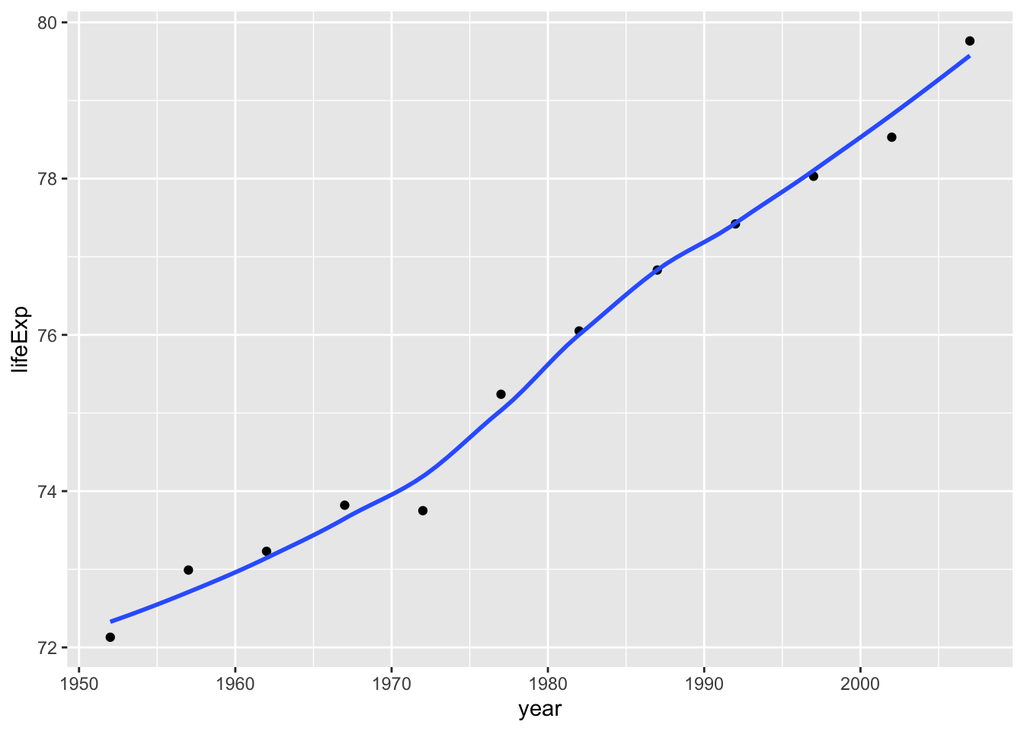

```r
plot1 <- ggplot(data = country_data, mapping = aes(x = year, y = lifeExp))+
  geom_point() +
  geom_smooth(se = FALSE)+
  NULL

plot1
```

Next we need to add a title. Create a new plot, or extend plot1, using the `labs()` function to add an informative title to the plot.

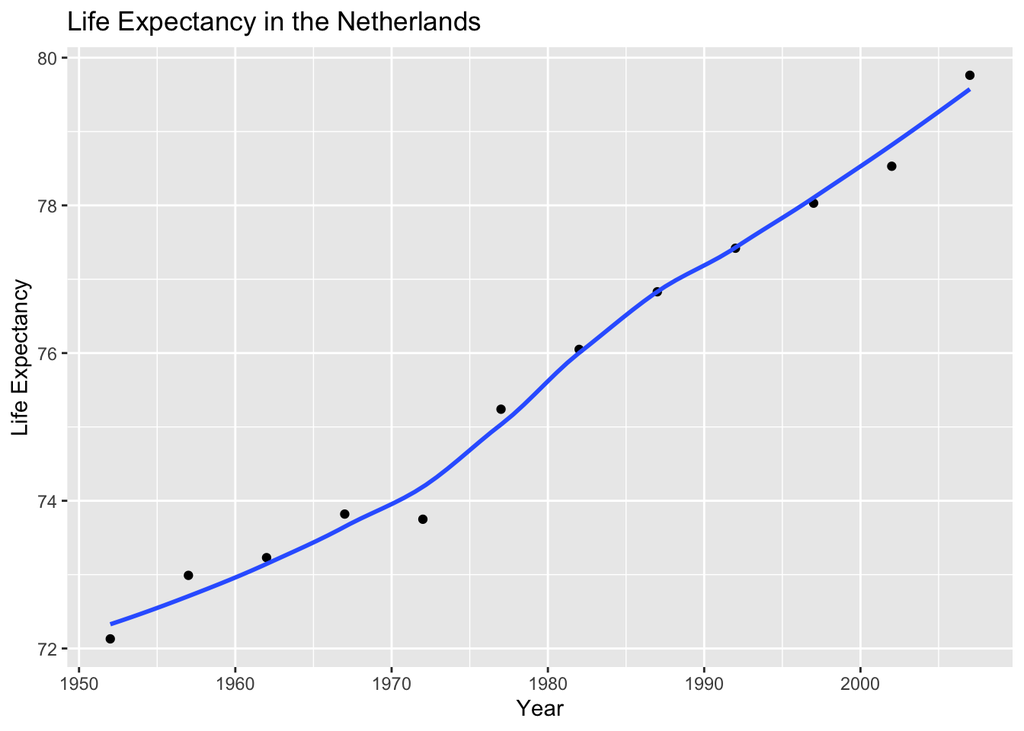

```r
plot1<- plot1 +
  labs(title = "Life Expectancy in the Netherlands",
      x = "Year",
      y = "Life Expectancy") +
  NULL


plot1
```

Secondly, produce a plot for all countries in the *continent* you come from. (Hint: map the `country` variable to the colour aesthetic. You also want to map `country` to the `group` aesthetic, so all points for each country are grouped together).

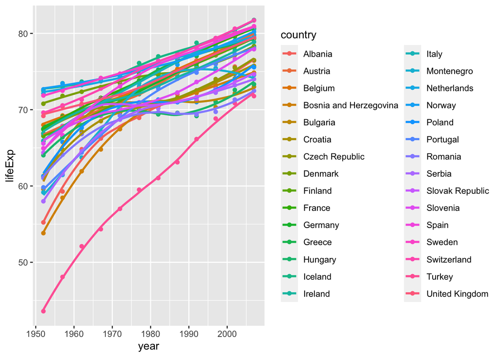

```r
ggplot(continent_data, mapping = aes(x = year , y =  lifeExp, colour= country, group = country))+
  geom_point() +
  geom_smooth(se = FALSE) +
  NULL
```

Finally, using the original `gapminder` data, produce a life expectancy over time graph, grouped (or faceted) by continent. We will remove all legends, adding the `theme(legend.position="none")` in the end of our ggplot.

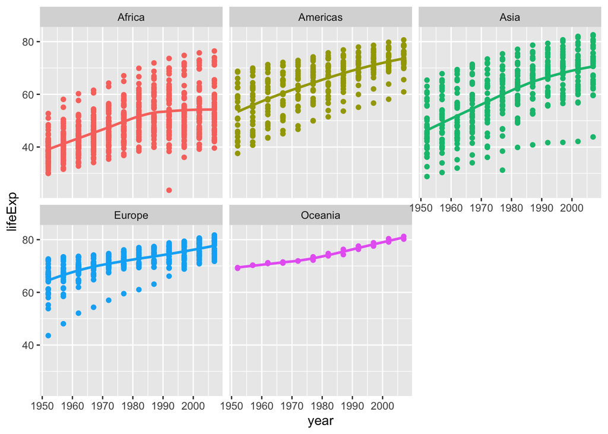

```r
ggplot(data = gapminder , mapping = aes(x = year , y = lifeExp , colour= continent))+
  geom_point() +
  geom_smooth(se = FALSE) +
  facet_wrap(~continent) +
  theme(legend.position="none") + #remove all legends
  NULL
```

Given these trends, what can you say about life expectancy since 1952? Again, don’t just say what’s happening in the graph. Tell some sort of story and speculate about the differences in the patterns.

> Type your answer after this blockquote.

Life expectancy in general has gone up, indicating an improvement in living conditions across the world, including but not limited to access to clean water, health care and food. A notable exception is Africa, where life expectancy has stagnated since 1990. The improvements in living conditions made elsewhere are not being transferred to Africa generally. Potentially, drought, famine and war could be the cause of this, which has affected other continents to a lesser extent. This has kept back the industrialisation and further development of Africa, while Asia, which started from a similar life expectancy, has made much larger improvements in both development and life expectancy.

# Task 3: Brexit vote analysis

We will have a look at the results of the 2016 Brexit vote in the UK. First we read the data using `read_csv()` and have a quick glimpse at the data

```r
# read data directly off github repo
brexit_results <- read_csv("https://raw.githubusercontent.com/kostis-christodoulou/am01/master/data/brexit_results.csv")


glimpse(brexit_results)
```

```
## Rows: 632
## Columns: 11
## $ Seat        <chr> "Aldershot", "Aldridge-Brownhills", "Altrincham and Sale W…
## $ con_2015    <dbl> 50.592, 52.050, 52.994, 43.979, 60.788, 22.418, 52.454, 22…
## $ lab_2015    <dbl> 18.333, 22.369, 26.686, 34.781, 11.197, 41.022, 18.441, 49…
## $ ld_2015     <dbl> 8.824, 3.367, 8.383, 2.975, 7.192, 14.828, 5.984, 2.423, 1…
## $ ukip_2015   <dbl> 17.867, 19.624, 8.011, 15.887, 14.438, 21.409, 18.821, 21.…
## $ leave_share <dbl> 57.89777, 67.79635, 38.58780, 65.29912, 49.70111, 70.47289…
## $ born_in_uk  <dbl> 83.10464, 96.12207, 90.48566, 97.30437, 93.33793, 96.96214…
## $ male        <dbl> 49.89896, 48.92951, 48.90621, 49.21657, 48.00189, 49.17185…
## $ unemployed  <dbl> 3.637000, 4.553607, 3.039963, 4.261173, 2.468100, 4.742731…
## $ degree      <dbl> 13.870661, 9.974114, 28.600135, 9.336294, 18.775591, 6.085…
## $ age_18to24  <dbl> 9.406093, 7.325850, 6.437453, 7.747801, 5.734730, 8.209863…
```

The data comes from [Elliott Morris](https://www.thecrosstab.com/), who cleaned it and made it available through his [DataCamp class on analysing election and polling data in R](https://www.datacamp.com/courses/analyzing-election-and-polling-data-in-r).

Our main outcome variable (or y) is `leave_share`, which is the percent of votes cast in favour of Brexit, or leaving the EU. Each row is a UK [parliament constituency](https://en.wikipedia.org/wiki/United_Kingdom_Parliament_constituencies).

To get a sense of the spread, or distribution, of the data, we can plot a histogram, a density plot, and the empirical cumulative distribution function of the leave % in all constituencies.

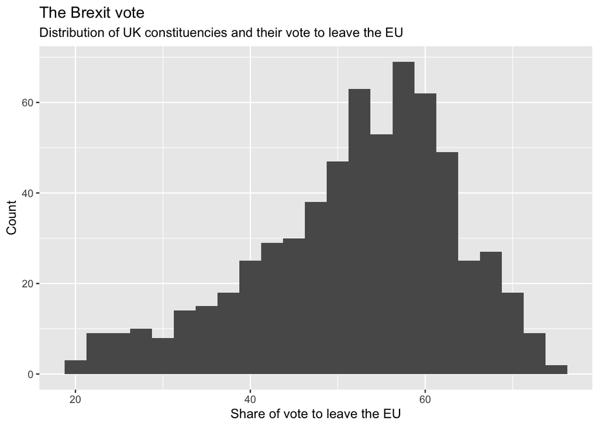

```r
# histogram
ggplot(brexit_results, aes(x = leave_share)) +
  geom_histogram(binwidth = 2.5) +
  labs(
    title = "The Brexit vote",
    subtitle = "Distribution of UK constituencies and their vote to leave the EU",
    x = 'Share of vote to leave the EU',
    y = 'Count'
  )
```

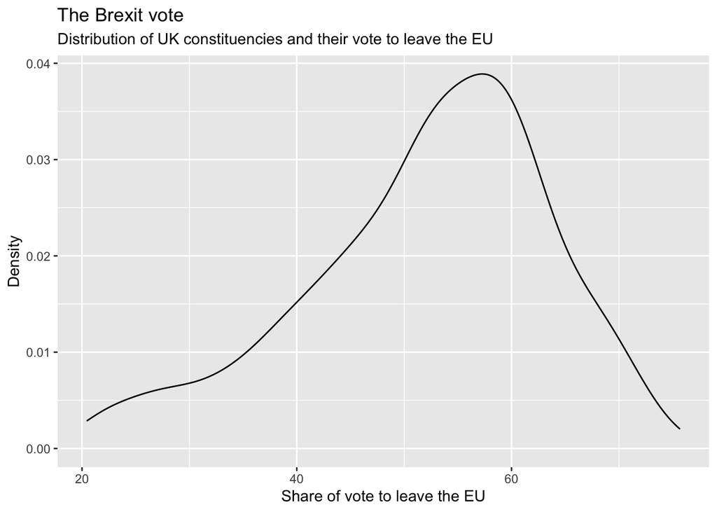

```r
# density plot-- think smoothed histogram
ggplot(brexit_results, aes(x = leave_share)) +
  geom_density()+
  labs(
    title = "The Brexit vote",
    subtitle = "Distribution of UK constituencies and their vote to leave the EU",
    x = 'Share of vote to leave the EU',
    y = 'Density'
  )
```

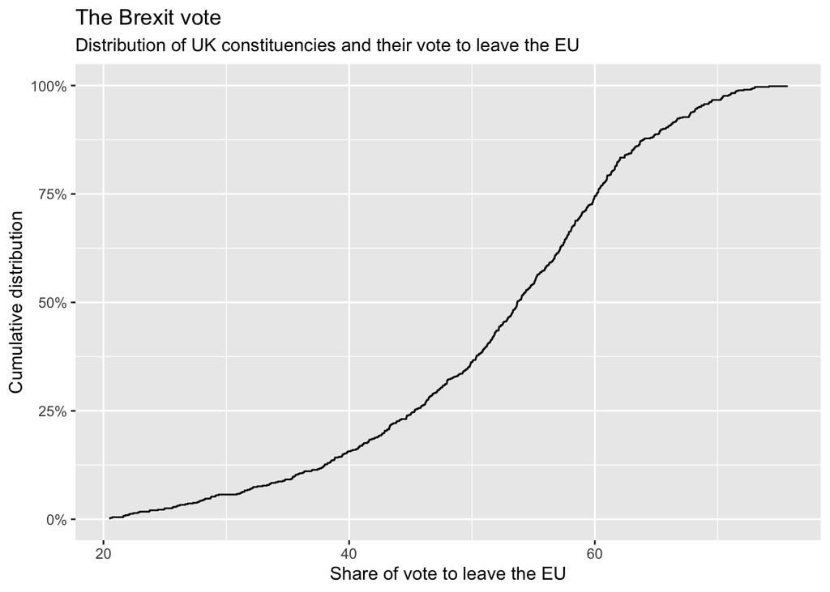

```r
# The empirical cumulative distribution function (ECDF)
ggplot(brexit_results, aes(x = leave_share)) +
  stat_ecdf(geom = "step", pad = FALSE) +
  scale_y_continuous(labels = scales::percent)+
  labs(
    title = "The Brexit vote",
    subtitle = "Distribution of UK constituencies and their vote to leave the EU",
    x = 'Share of vote to leave the EU',
    y = 'Cumulative distribution'
  )
```

One common explanation for the Brexit outcome was fear of immigration and opposition to the EU’s more open border policy. We can check the relationship (or correlation) between the proportion of native born residents (`born_in_uk`) in a constituency and its `leave_share`. To do this, let us get the correlation between the two variables

```r
brexit_results %>%
  select(leave_share, born_in_uk) %>%
  cor()
```

```
##             leave_share born_in_uk
## leave_share   1.0000000  0.4934295
## born_in_uk    0.4934295  1.0000000
```

The correlation is almost 0.5, which shows that the two variables are positively correlated.

We can also create a scatterplot between these two variables using `geom_point`. We also add the best fit line, using `geom_smooth(method = "lm")`.

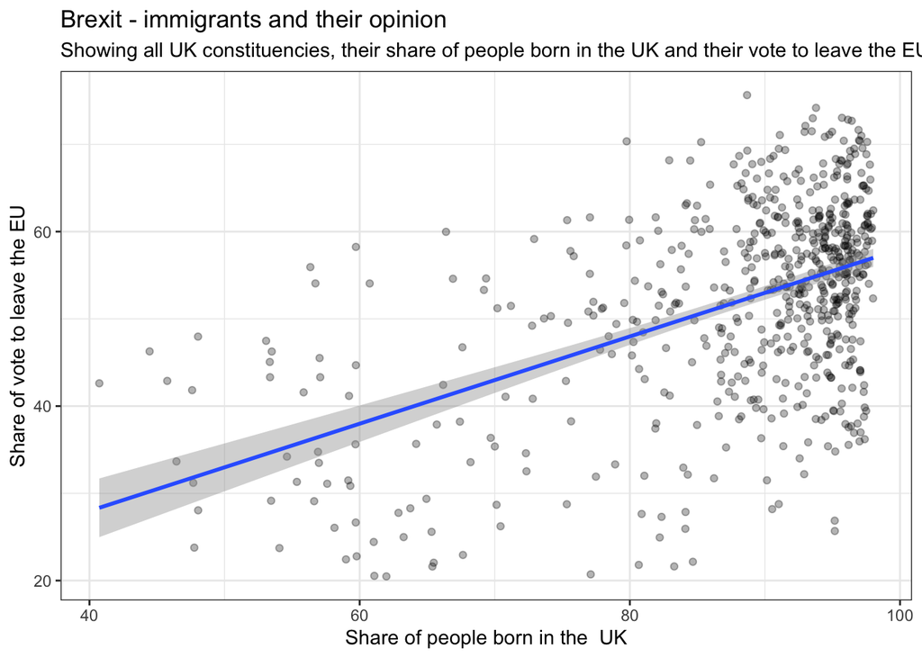

```r
ggplot(brexit_results, aes(x = born_in_uk, y = leave_share)) +
  geom_point(alpha=0.3) +

  # add a smoothing line, and use method="lm" to get the best straight-line
  geom_smooth(method = "lm") +

  # use a white background and frame the plot with a black box
  theme_bw() +

  labs(
    title = "Brexit - immigrants and their opinion",
    subtitle = "Showing all UK constituencies, their share of people born in the UK and their vote to leave the EU",
    x = 'Share of people born in the  UK',
    y = 'Share of vote to leave the EU'
  )
```

You have the code for the plots, I would like you to revisit all of them and use the `labs()` function to add an informative title, subtitle, and axes titles to all plots.

What can you say about the relationship shown above? Again, don’t just say what’s happening in the graph. Tell some sort of story and speculate about the differences in the patterns.

> Type your answer after, and outside, this blockquote.

While it is visually not a strong relationship, statistically constituencies with a larger share of people born in the UK have a larger share of people voting to leave the EU. There could be several explanations for this fact. One of them, is that immigrants are more likely to support staying in the EU, considering that many of them likely come from the EU or at least see the value of freeer movement of people and goods. Another explanation, is that those UK-born people living with more immigrants also see that they are not only out to steal their jobs, but are regular people, living, working and paying their taxes. Considering that recent immigrants are not allowed to vote, not all people not born in the UK are from the EU, and not all people vote in general, a combination of the two explanations is likely at work.

# Task 4: Animal rescue incidents attended by the London Fire Brigade

[The London Fire Brigade](https://data.london.gov.uk/dataset/animal-rescue-incidents-attended-by-lfb) attends a range of non-fire incidents (which we call ‘special services’). These ‘special services’ include assistance to animals that may be trapped or in distress. The data is provided from January 2009 and is updated monthly. A range of information is supplied for each incident including some location information (postcode, borough, ward), as well as the data/time of the incidents. We do not routinely record data about animal deaths or injuries.

Please note that any cost included is a notional cost calculated based on the length of time rounded up to the nearest hour spent by Pump, Aerial and FRU appliances at the incident and charged at the current Brigade hourly rate.

```r
url <- "https://data.london.gov.uk/download/animal-rescue-incidents-attended-by-lfb/f43b485e-fb35-419c-aa7a-fa75676e5835/Animal%20Rescue%20incidents%20attended%20by%20LFB%20from%20Jan%202009.csv"

animal_rescue <- read_csv(url, locale = locale(encoding = "CP1252")) %>%
  janitor::clean_names()


glimpse(animal_rescue)
```

```
## Rows: 8,751
## Columns: 31
## $ incident_number               <chr> "139091", "275091", "2075091", "2872091"…
## $ date_time_of_call             <chr> "01/01/2009 03:01", "01/01/2009 08:51", …
## $ cal_year                      <dbl> 2009, 2009, 2009, 2009, 2009, 2009, 2009…
## $ fin_year                      <chr> "2008/09", "2008/09", "2008/09", "2008/0…
## $ type_of_incident              <chr> "Special Service", "Special Service", "S…
## $ pump_count                    <chr> "1", "1", "1", "1", "1", "1", "1", "1", …
## $ pump_hours_total              <chr> "2", "1", "1", "1", "1", "1", "1", "1", …
## $ hourly_notional_cost          <dbl> 255, 255, 255, 255, 255, 255, 255, 255, …
## $ incident_notional_cost        <chr> "510", "255", "255", "255", "255", "255"…
## $ final_description             <chr> "Redacted", "Redacted", "Redacted", "Red…
## $ animal_group_parent           <chr> "Dog", "Fox", "Dog", "Horse", "Rabbit", …
## $ originof_call                 <chr> "Person (land line)", "Person (land line…
## $ property_type                 <chr> "House - single occupancy", "Railings", …
```

[output cut: 18 more lines]

One of the more useful things one can do with any data set is quick counts, namely to see how many observations fall within one category. For instance, if we wanted to count the number of incidents by year, we would either use `group_by()... summarise()` or, simply [`count()`](https://dplyr.tidyverse.org/reference/count.html)

```r
animal_rescue %>%
  dplyr::group_by(cal_year) %>%
  summarise(count=n())
```

```
## # A tibble: 14 × 2
##    cal_year count
##       <dbl> <int>
##  1     2009   568
##  2     2010   611
##  3     2011   620
##  4     2012   603
##  5     2013   585
##  6     2014   583
##  7     2015   540
##  8     2016   604
##  9     2017   539
## 10     2018   610
## 11     2019   604
## 12     2020   758
## 13     2021   885
## 14     2022   641
```

```r
animal_rescue %>%
  count(cal_year, name="count")
```

```
## # A tibble: 14 × 2
##    cal_year count
##       <dbl> <int>
##  1     2009   568
##  2     2010   611
##  3     2011   620
##  4     2012   603
##  5     2013   585
##  6     2014   583
##  7     2015   540
##  8     2016   604
##  9     2017   539
## 10     2018   610
## 11     2019   604
## 12     2020   758
## 13     2021   885
## 14     2022   641
```

Let us try to see how many incidents we have by animal group. Again, we can do this either using group_by() and summarise(), or by using count()

```r
animal_rescue %>%
  group_by(animal_group_parent) %>%

  #group_by and summarise will produce a new column with the count in each animal group
  summarise(count = n()) %>%

  # mutate adds a new column; here we calculate the percentage
  mutate(percent = round(100*count/sum(count),2)) %>%

  # arrange() sorts the data by percent. Since the default sorting is min to max and we would like to see it sorted
  # in descending order (max to min), we use arrange(desc())
  arrange(desc(percent))
```

```
## # A tibble: 28 × 3
##    animal_group_parent              count percent
##    <chr>                            <int>   <dbl>
##  1 Cat                               4232   48.4
##  2 Bird                              1803   20.6
##  3 Dog                               1341   15.3
##  4 Fox                                455    5.2
##  5 Unknown - Domestic Animal Or Pet   215    2.46
##  6 Horse                              201    2.3
##  7 Deer                               152    1.74
##  8 Unknown - Wild Animal              102    1.17
##  9 Squirrel                            75    0.86
## 10 Unknown - Heavy Livestock Animal    50    0.57
## # … with 18 more rows
```

```r
animal_rescue %>%

  #count does the same thing as group_by and summarise
  # name = "count" will call the column with the counts "count" ( exciting, I know)
  # and 'sort=TRUE' will sort them from max to min
  count(animal_group_parent, name="count", sort=TRUE) %>%
  mutate(percent = round(100*count/sum(count),2))
```

```
## # A tibble: 28 × 3
##    animal_group_parent              count percent
##    <chr>                            <int>   <dbl>
##  1 Cat                               4232   48.4
##  2 Bird                              1803   20.6
##  3 Dog                               1341   15.3
##  4 Fox                                455    5.2
##  5 Unknown - Domestic Animal Or Pet   215    2.46
##  6 Horse                              201    2.3
##  7 Deer                               152    1.74
##  8 Unknown - Wild Animal              102    1.17
##  9 Squirrel                            75    0.86
## 10 Unknown - Heavy Livestock Animal    50    0.57
## # … with 18 more rows
```

Do you see anything strange in these tables?

Finally, let us have a loot at the notional cost for rescuing each of these animals. As the LFB says,

> Please note that any cost included is a notional cost calculated based on the length of time rounded up to the nearest hour spent by Pump, Aerial and FRU appliances at the incident and charged at the current Brigade hourly rate.

There is two things we will do:

1. Calculate the mean and median `incident_notional_cost` for each `animal_group_parent`
2. Plot a boxplot to get a feel for the distribution of `incident_notional_cost` by `animal_group_parent`.

Before we go on, however, we need to fix `incident_notional_cost` as it is stored as a `chr`, or character, rather than a number.

```r
# what type is variable incident_notional_cost from dataframe `animal_rescue`
typeof(animal_rescue$incident_notional_cost)
```

```
## [1] "character"
```

```r
# readr::parse_number() will convert any numerical values stored as characters into numbers
animal_rescue <- animal_rescue %>%

  # we use mutate() to use the parse_number() function and overwrite the same variable
  mutate(incident_notional_cost = parse_number(incident_notional_cost))

# incident_notional_cost from dataframe `animal_rescue` is now 'double' or numeric
typeof(animal_rescue$incident_notional_cost)
```

```
## [1] "double"
```

Now that incident_notional_cost is numeric, let us quickly calculate summary statistics for each animal group.

```r
animal_rescue %>%

  # group by animal_group_parent
  group_by(animal_group_parent) %>%

  # filter resulting data, so each group has at least 6 observations
  filter(n()>6) %>%

  # summarise() will collapse all values into 3 values: the mean, median, and count
  # we use na.rm=TRUE to make sure we remove any NAs, or cases where we do not have the incident cos
  summarise(mean_incident_cost = mean (incident_notional_cost, na.rm=TRUE),
            median_incident_cost = median (incident_notional_cost, na.rm=TRUE),
            sd_incident_cost = sd (incident_notional_cost, na.rm=TRUE),
            min_incident_cost = min (incident_notional_cost, na.rm=TRUE),
            max_incident_cost = max (incident_notional_cost, na.rm=TRUE),
            count = n()) %>%

  # sort the resulting data in descending order. You choose whether to sort by count or mean cost.
  arrange(desc(mean_incident_cost))
```

```
## # A tibble: 17 × 7
##    animal_group_parent             mean_…¹ media…² sd_in…³ min_i…⁴ max_i…⁵ count
##    <chr>                             <dbl>   <dbl>   <dbl>   <dbl>   <dbl> <int>
##  1 Horse                              735.    596    536.      255    3480   201
##  2 Cow                                599.    436    451.      260    1560     9
##  3 Unknown - Wild Animal              422.    333    318.      260    2296   102
##  4 Deer                               421.    339    276.      260    2340   152
##  5 Fox                                382.    339    200.      255    2034   455
##  6 Snake                              375.    352    122.      260     704    20
##  7 Unknown - Heavy Livestock Anim…    374.    260    263.      255    1560    50
##  8 Sheep                              355.    339    114.      255     596     7
##  9 Dog                                353.    326    182.        0    3168  1341
## 10 Cat                                351.    326    163.        0    3912  4232
## 11 Bird                               349.    328    138.      255    1788  1803
## 12 Unknown - Domestic Animal Or P…    331.    298    119.      255    1300   215
## 13 cat                                329.    310.    87.4     260     596    20
## 14 Squirrel                           318.    328     55.6     255     678    75
## 15 Hamster                            317.    290     92.5     260     652    17
## 16 Rabbit                             315.    330.    34.4     255     364    16
## 17 Ferret                             314.    336     41.1     260     364    10
## # … with abbreviated variable names ¹mean_incident_cost, ²median_incident_cost,
## #   ³sd_incident_cost, ⁴min_incident_cost, ⁵max_incident_cost
```

Compare the mean and the median for each animal group. What do you think this is telling us? Anything else that stands out? Any outliers?

The mean and the median move in sync in general, with higher means having higher medians as well. Some exceptions are the horse and the unknown - heavy livestock animal types, which have a high mean but a much lower (relatively) median. This means that we had some high outliers in cost, driving up the mean cost. The squirrel, rabbit and ferret have the opposite, where the median cost is higher than the mean incident cost. This difference could be due to the value people place in the animal. Horses and heavy livestock are worth a lot more than squirrels, rabbit and ferrets, causing the owners to urge the fire brigade to go above and beyond. Another related reason is the size of the animal, smaller animals cost less manpower, machines and time to rescue usually than larger animals.

Finally, let us plot a few plots that show the distribution of incident_cost for each animal group.

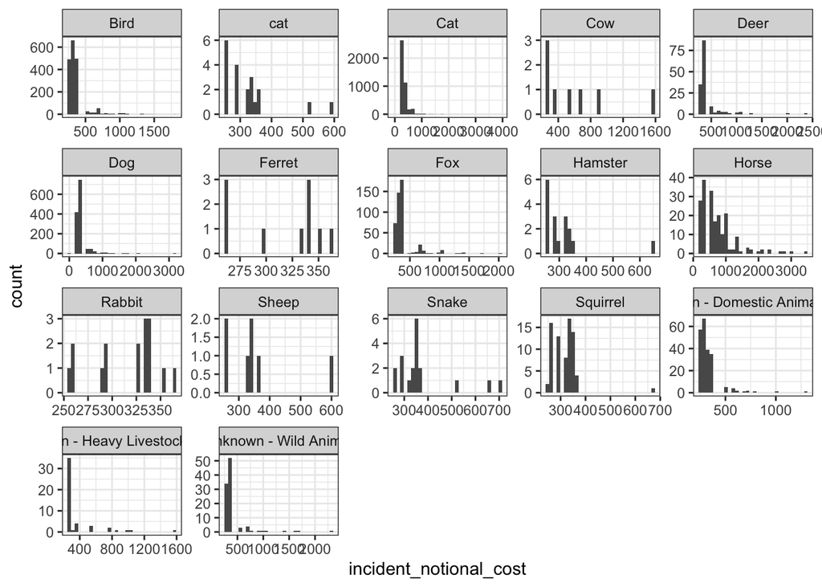

```r
# base_plot
base_plot <- animal_rescue %>%
  group_by(animal_group_parent) %>%
  filter(n()>6) %>%
  ggplot(aes(x=incident_notional_cost))+
  facet_wrap(~animal_group_parent, scales = "free")+
  theme_bw()

base_plot + geom_histogram()
```

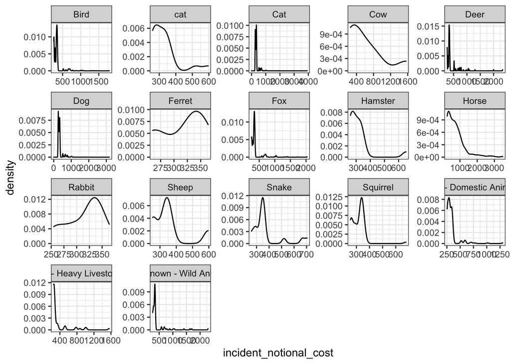

```r
base_plot + geom_density()
```

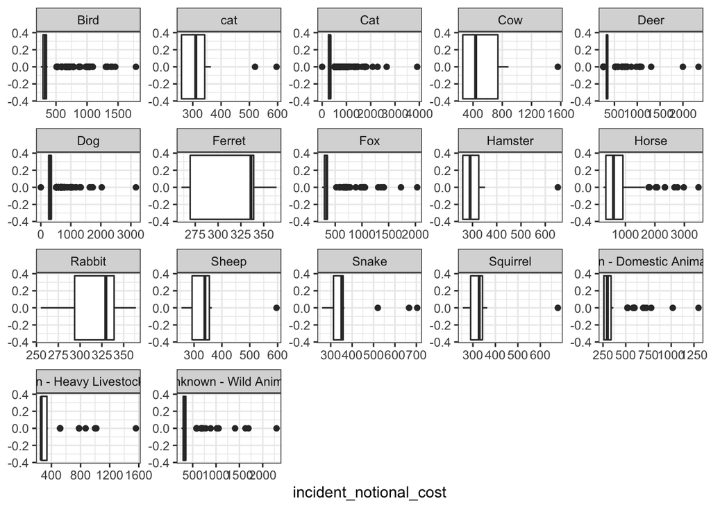

```r
base_plot + geom_boxplot()
```

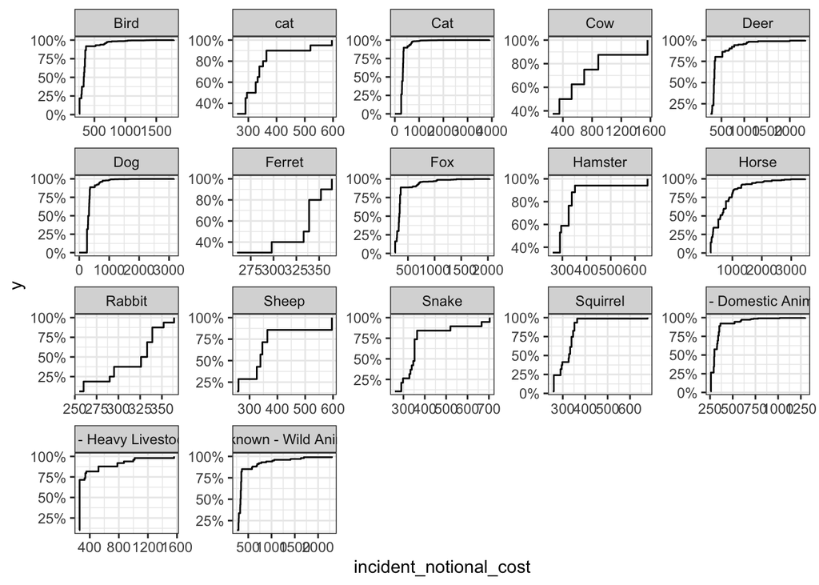

```r
base_plot + stat_ecdf(geom = "step", pad = FALSE) +
  scale_y_continuous(labels = scales::percent)
```

Which of these four graphs do you think best communicates the variability of the `incident_notional_cost` values? Also, can you please tell some sort of story (which animals are more expensive to rescue than others, the spread of values) and speculate about the differences in the patterns.

An issue with all of the graphs is that the x axis of notional cost does not match across the different graphs, making direct comparisons much harder. We are now more likely to compare the relative spread and variability rather than directly compare the cost of rescuing each animal type. In my opinion, the density plot best communicates the variability. The bar plot communicates a definitiveness that does not exist, this spread of values is only a limited timeframe and thus this variability does not have to stay fixed. The density plot is intuitive to understand, showing where there’s more animals and where there’s less, even if it makes some generalisations on the pattern. The box plot is a good alternative, but for especially small distributions it is harder to understand, with a line at 1 point and dots at others. The final cumulative plot is not intuitive, as the it is not mentioned clearly that it is cumulative and that is not something that is used often. It is also visually more difficult to interpret a cumulative height difference compared to an absolute height, so the density plot would be better.

# Submit the assignment

Knit the completed R Markdown file as an HTML document (use the “Knit” button at the top of the script editor window) and upload it to Canvas.

## Details

If you want to, please answer the following

- Who did you collaborate with: No one
- Approximately how much time did you spend on this problem set: roughly an hour
- What, if anything, gave you the most trouble: Looking for an interesting interpretation.